# 9.1 - Analysis of primary outcome by receipt of anti-inflammatory medication

Published

July 26, 2023

## Definition

The relevant anti-inflammatory medications were:

- corticosteroids
- tocilizumab
- baricitinib

Technically, receipt of anti-inflammatory medications is a post-randomisation event. Therefore, without strong assumptions, the interpretation of a within group effect is challening, particularly given the trial was open-label.

## Results

There were 130 participants out of 155 who received anti-inflammatory medication during their hospital stay. There were 60 who received corticosteroids only, 57 who received corticosteroids with baricitinib, 8 who received corticosteroids with tocilizumab, and 5 who received baricitinib only. There remaining 25 participants received no anti-inflammatory medication.

| receipt_antiinflam | n |
| --- | --- |
| 0 | 25 |
| 1 | 130 |

| receipt_antiinflam | DIS_ImmunoCorticosteroids | DIS_ImmunoTocilizumab | DIS_ImmunoBaricitinib | n |
| --- | --- | --- | --- | --- |
| 0 | No | No | No | 25 |
| 1 | No | No | Yes | 5 |
| 1 | Yes | No | No | 60 |
| 1 | Yes | No | Yes | 57 |
| 1 | Yes | Yes | No | 8 |

No participant who did not receive anti-inflammatory medication met the primary outcome. Of the 130 participants who did receive anti-inflammatory medication, 12 (9%) met the primary outcome.

| receipt_antiinflam | n | na | y |
| --- | --- | --- | --- |
| 0 | 25 | 0 | 0 |
| 1 | 130 | 0 | 12 |

Amongst the 73 participants assigned to standard of care, 58 (79%) received anti-inflammatory medications and 8 (14%) of these met the primary outcome. Amongst the 82 participants assigned to nafamostat, 72 (88%) received anti-inflammatory medications and 4 (6%) met the primary outcome.

| receipt_antiinflam | n_A1 | y_A1 | n_A2 | y_A2 |
| --- | --- | --- | --- | --- |
| 0 | 15 | 0 | 10 | 0 |
| 1 | 58 | 8 | 72 | 4 |

### Subgroup Analysis

|  | Intervention | events/patients |
| --- | --- | --- |
| Anti-inflammatory |  |  |
| Did not receive anti-inflammatory | SoC | 0/15 (0.00) |
| Did not receive anti-inflammatory | Nafamostat | 0/10 (0.00) |
| Received anti-inflammatory | SoC | 8/58 (0.14) |
| Received anti-inflammatory | Nafamostat | 4/72 (0.06) |

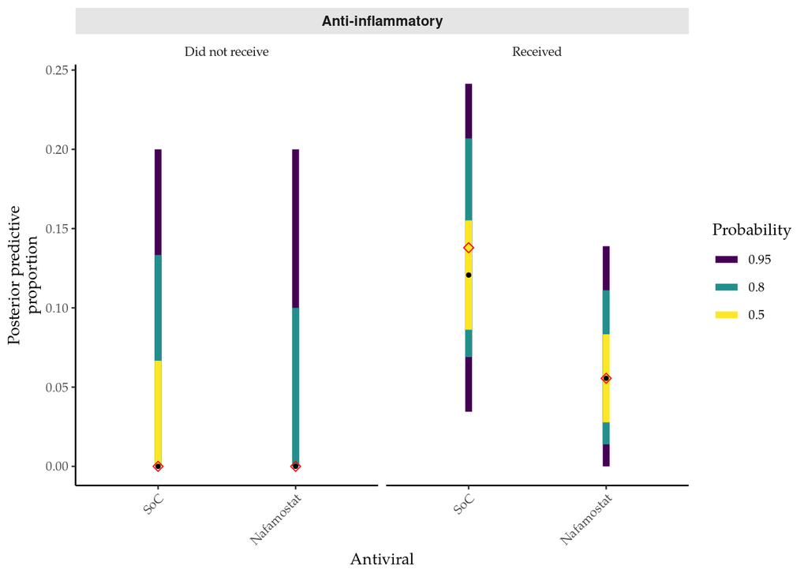

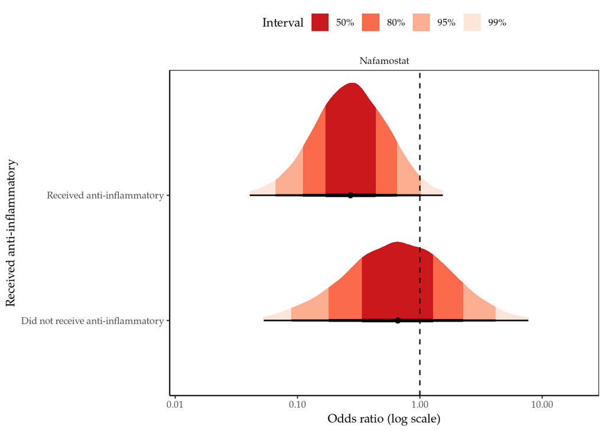

[output not shown]

[output not shown]